[figure not shown]

Screenshots of editors, pros/cons, GUI editors, Rabix, Galaxy, and Taverna

Installing Nextflow has been a trial

Immediately Nextflow is a little weird, and the documentation doesn't seem quite as beginner friendly. They do a decent job saying

how to do something, but they haven't explained the concepts well from the get go.

Nextflow is a good bit more intuitive than Snakemake, and I think a large part of my confusion is coming from not knowing Groovy.

Although they do tend to simply introduce stuff without explaining it a good amount.

They have a set of pipelines called nf-core! https://nf-co.re/

Wow Nextflow is annoying as heck. Installation sux, java sux, nf-core keeps failing, looking at logs is incomprehensible, no large

groovy community that has run into many issues and can help you, groovy documentation is annoying as heck need to literally learn

all that language.

The -resume option seems to have worked and feels nice :)

I ran into several issues: first off STAR doesn't work on my computer because I run out of memory and stuff just fails. Then I tried it on

the servers, but docker wouldn't work so I needed singulairity. With singulairity I ran into issues where the images would not get

pulled down randomly. The workflow would occaisonally work, but inconsistent which was worrysome. I don't actually know if it was

fully broken or not. Nextflow returned what command didn't work, and there was a strange space in it, I then ran it on my shell

normally to see what happens, and it might be coincidence but the workflow worked after that. I made a conda env to make this

download consistent, but in general this was a very annoying process to go through.

I was looking for this functionality, and looks like it doesn't continually pull :)

Thoughts/Opinions

4:11 PM

[figure not shown]

It wants versions between 8-15 and doesn't tell you the issue if you have a newer version.

https://stackoverflow.com/questions/68935140/nextflow-installation-cannot-find-java From here user

tgdavies recommended just adding a |16 to line 336 of the file. I tried, it didn't work, so I'm just

downloading the openjdk version 15 from https://jdk.java.net/archive/.

I ran into antoher issue!

It said:

Error: Could not find or load main class NextflowLoader

Caused by: java.lang.ClassNotFoundException: NextflowLoader

Unable to initialize nextflow environment

Well turns out the linux subsystem is literally a linux system, so I kept wrongly downloading the windows

version when I should've been getting the linux one -_- Worked like a charm to get the version 15 linux

download from https://jdk.java.net/archive/.

Installation

Wednesday, August 11, 2021

4:11 PM

Nextflow Page 2

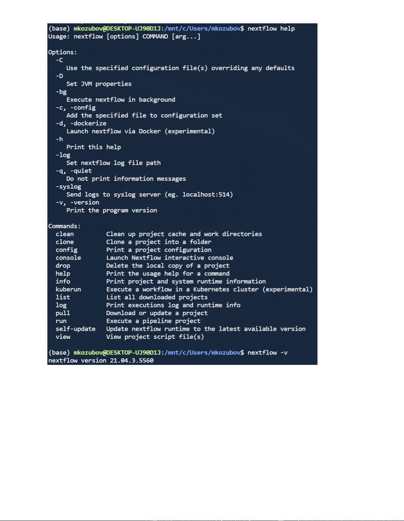

Well I am insanely dumb, because conda can do all the work for us!!!!!

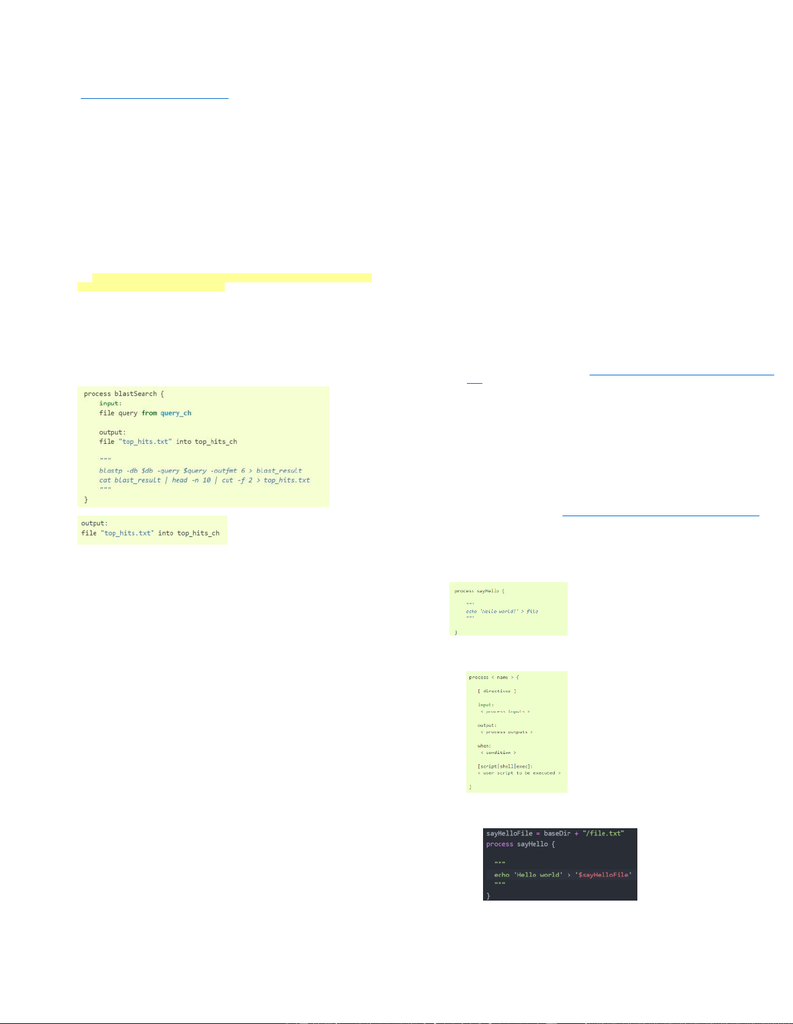

Tutorial link: https://www.nextflow.io/docs/latest/getstarted.html

My first script:

Well first off this is a pretty disorienting start. They give me a script and I don't fully understand the

layout. Turns out parallel processes don't run in the same order, so different resutls can print before

others.

Very nice feature is that Nextflow immediately produces logs, no need for the user to make them,

although they are a bit incomprehensible.

It creates a weird work file that I simply do not understand.

Modify and resume:

Huge quality of life improvement over Snakemake: if a piece of script is changed, that portion alone

is re-run. No weird work around is needed like for Snakemake.

Just need to rerun the command with "nextflow run tutorial.nf -resume"

KEY: Cached information is stored in ./work directory. This may take up a lot of space, so if I don't

plan to resume the pipeline, clean out this folder.

Pipeline parameters:

They don't really describe what a pipeline parameter is, but we can make one simply by having the

prefix "params.NAME". The value of the parameter can be specified at the commandline with --

NAME.

Basic concepts:

Process and channels:

Nextflow ties together a bunch of scripting languages that can be executed on linux.

Process=task

Channel=asynchronous queue (outputs go into channels?)

Links are not established based on naming schemes! They are based on whether a channel is

defined in the input or the output.

Execution abstraction:

Process defines what a command has to execute, the executor determines how the script is run. By

default the executor is the local computer.

Configuration options:

Define properties in the .config file which should live in the same directory. Here we can define

which executor to use "Cloud, HPC, Job scheduler, local" and any local process environment

variables.

Groovy Language Basics:

Looks like in the .nf file, you can just type a Groovy syntaxed command and it will run as if it were its own stand

alone language.

Note editing the script in anyway reruns other processes it looks like

Lists and dictionaries look similar to python, although they call dict maps.

If/else is done with

if (x < 0.5) {

}

Else {

Println "You won!"

}

Within quotes you can access variables with $foxtype ${foxcolor.join()} can run an expression. Without quotes

just foxtype or baseDir will do.

Like on bash using the \ inside of a multiline string will negate the \n

Within a process {} the "task" keyword can let you access variables you have defined.

You can make a type of generator (python) using curly braces when defining a variable.

This honestly feels like a lambda maybe?

"square = { it * it }"

Not super interesting until it is connected to other functions to string along stuff.

[1,2,3,4].collect(square)

This says make the array, and run square on each element, collecting them in another array.

Can have multiple variables not just "it".

https://stackoverflow.com/questions/2993462/groovy-what-does-

mean This post describes what the -> operator does.

Basic read/write:

Create a file variable using file(/path/to/file/or/directory). Then we can see the contents of the file with myFile.text

operation.

We can append to the file using myFile.append("add this line\n") or myFile << "add a line more\n".

Reading line by line:

Similar to python

allLines = myFile.readLines()

For (line : allLines){stuff}

Reading line by line for big files we can use eachLine. eachLine makes use of the closure stuff we learned

earlier so it might take some getting used to.

Extensive file and directory movement: https://www.nextflow.io/docs/latest/script.html#list-directory-content

Processes:

Super basic process definition:

Needs the keyword process, a name, and curly braces. Inside the curlies we need at least one bit of executable

script.

Processes structure:

We can have 5 elements in a process. Except my script doesn't seem to work :(

Wow that was annoying. So the base output of a bash script goes into the work/ directory and within that

into other weird subdirectories??? To get the file to write to my baseDir I had to do a little work around:

The single quotes around the variable expansion are important for me because my directory path has

spaces, causing Bash to freak out. This way the stuff expands inside of them, but the linux knows that it is

all one unit.

Scripting:

We can use different languages by specifying with a shebang what language we intend the script portion

to be executed in.

Basic Tutorial

Wednesday, August 11, 2021

4:23 PM

Nextflow Page 4

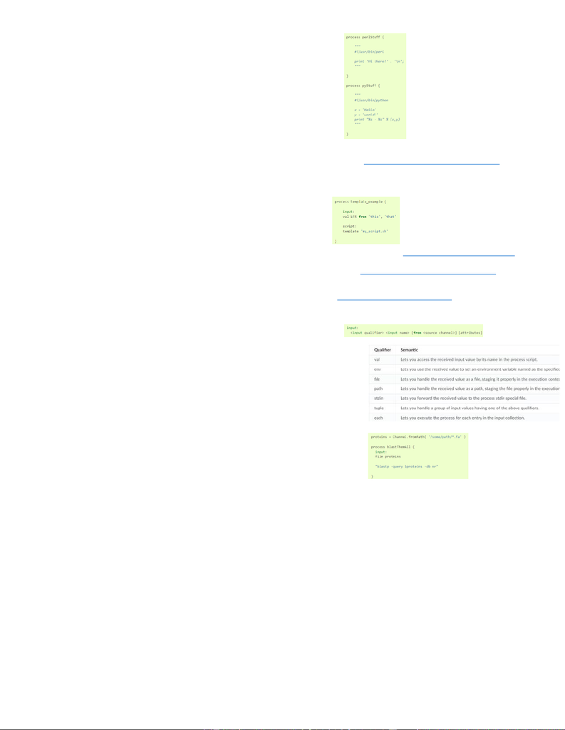

To generalize the above code to most if not all systems, use #!/user/bin/env python

Conditional scripts:

https://www.nextflow.io/docs/latest/process.html#scripts-a-la-carte

We can make the script and if() else if() else() by prefixing the '''''' with "script:"

Template modularization:

We also have the shell directive:

https://www.nextflow.io/docs/latest/process.html#shellwhich lets us use

scripts similar to script, but lets us use both nextflow variables and bash variables.

Native execution:

https://www.nextflow.io/docs/latest/process.html#native-execution

We can have something execute natively without the shell using the exec: command and some groovy

language.

Inputs:

https://www.nextflow.io/docs/latest/process.html#inputs

Processes are somewhat isolated but can send over values through channels.

Rules: Only one input block per channel, and it must have one or more input declarations?

Syntax:

Qualifier is the type of data

If the input name is the same as the channel name, then the from … part can be omited and it looks like

this:

Pretty neat functionality, but if you have a bunch of files in a directory, but want them to end up

having the same name, you can do "file "fastafile" from proteins" and if you echo it, it will look

like fastafile1 fastafile2 …

□

So to summarize:

If we have a channel, we can put the list into a variable using from, and access it from the

commandline command using ${query_file}. If the variable name will be the same as the channel

name we can just do file proteins and access it using $proteins. If wawant to have all the channel

list stuff have the same name, we name it 'query.fa' and access it just as query.fa. If we use a

wildcard the 'query*.fa' will transform into 'query1.fa' 'query2.fa' etc.

□

Input types:

[figure not shown]

Documentation: http://groovy-lang.org/documentation.html

Cheat Sheet: http://www.cheat-sheets.org/saved-copy/rc015-groovy_online.pdf

(Very) Recommended book: https://www.manning.com/books/groovy-in-action-second-edition

Groovy Book

Groovy Tutorial

Monday, August 30, 2021

4:06 PM

Nextflow Page 6

[figure not shown]

https://www.nextflow.io/blog/2020/learning-nextflow-in-2020.html

Nextflow sponsored tutorial

Monday, September 20, 2021

8:58 AM

Nextflow Page 7

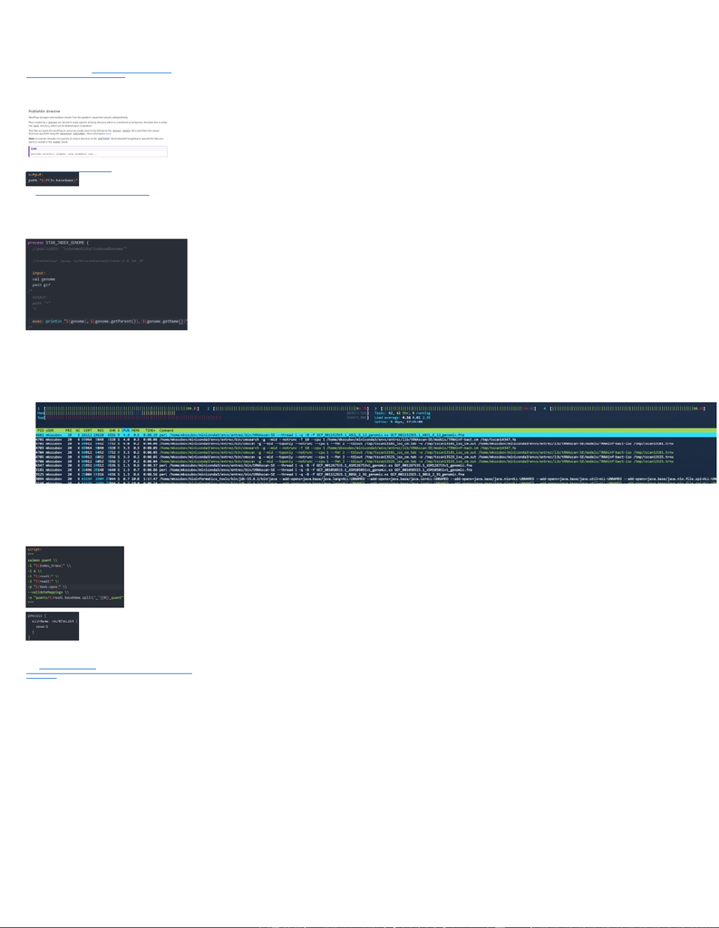

Going to try and automate this pipeline: https://bioinformatics.uconn.edu/resources-and-

events/tutorials-2/rna-seq-tutorial-with-reference-genome/#

I am encountering an issue where the path to a file disappears :\ That doesn't seem like the intended

activity, yet it is happening and I am very confused. Nextflow takes your path and moves that file to the

work dir were the full path isn't needed!

This is how you deal with intermediate files!

Holy balls I was struggling to get the filename, but leave off the extension, well:

https://github.com/nextflow-io/nextflow/issues/278 this is how you do it

So simple. There is also a left ready version .simpleName which will get the far left period rather than far

right. https://www.nextflow.io/docs/latest/script.html#check -file-attributes here is where it is

mentioned in the Docs.

My workflow seems to be working so far :) Turns out if I want the container directive to work, I need to

have a configuration file with docker.enable = true in there.

I think task basically refers to self and can be used to access directives such as task.cpus

How to view an input directly and print it to the console:

=====================================================================================

=======================================================================

Now I kind of want to try and make a pipeline of my own to automate pulling down genomes, and

performing tRNAscan-SE on them :)

So many issues -_-

Nextflow has a hardtime mutating channels. Example I get a directory out, but a file with specific

filenames. It is very tough to do dir+filename to make a new channel full of these.

1.

Reading data to use as inputs from a file is clunky and difficult

2.

I don't yet understand how to string together subworkflows

3.

I can limit cpu usage of one run of a tool, but because it works in parallel, it devours all available

resources once it parallizes. In my old lab I was told not to exceed 80% usage or else it is bad for

the server. No clue how to impose a global limit.

4.

I haven't even gotten to containerization yet

5.

A test set may not be exhaustive, so when you get to the end of the program, something might

error. If a tool errors, you can generally fix it and click resume, but if it was an issue with the

pipeline itself, you are SOL, fix the script, rerun it. Building pipelines on our own without

consulting someone that knows nextflow or groovy well may be incredibly tedious and difficult.

6.

The filestructure of nextflow is not immediately intuitive when you need to aggregate data. I think

I found a way around it with the .collect() method, but there is an issue if the filenames generated

are the same.

7.

=====================================================================================

===========================================================================

They don’t make this super clear, but you can define a process specific cpu/memory usage requirement

in the configuration file, then reference it within the actual process in the .nf file using task.cpus or

task.memory.

Another issue!!!!!!!!!!!!!!!!!!!!!!!!!!!!!!

If I have channels with incongruent number of inputs, especially 1 to many like in my salmon example

above (1 reference transcriptome to be reused for many different pairs of read1 and read2), then we

can make the single value channel into a true VALUE channel by using the .first() method for some

reason: https://seqera.io/training/#_inputs (ctrl-f cardinality) and the solution is in

https://stackoverflow.com/questions/53972302/nextflow -is-it-possible-to-tranform-a-queue-channel-

to-a-value-channel.

Doing stuff

Friday, September 17, 2021

12:55 PM

Nextflow Page 8

[figure not shown]

https://www.nextflow.io/docs/latest/index.html

This is their written documenatation

The layout of this is as follows

Your first script

•

Basic concepts

•

Nextflow scripting

•

Processes

•

Channels

•

Operators

•

Executors

•

Configuration

•

DSL 2

•

CLI

•

Clouds

Amazon cloud

▪

Azure Cloud

▪

Google cloud

▪

•

Conda env

•

Containers

Docker containers

▪

Shifter containers

▪

Singularity containers

▪

Podman containers

▪

Charliecloud containers

▪

•

Apache ignite

•

Kubernetes

•

Tracing and visualization

•

Pipeline sharing

•

Workflow introspection

•

Mail and notifications

•

Plugins

•

https://www.nextflow.io/presentations.html

Presentations and video tutorials

https://carpentries-incubator.github.io/workflows-nextflow/aio/index.html

Tutorial and overview of Nextflow

Trouble shooting nf-core: https://nf-co.re/usage/troubleshooting#the-pipeline-crashes-almost-

immediately-with-an-early-pipeline-step, this seems related to my issues https://github.com/nf-

core/rnaseq/issues/494

Wow I am big dumb, look at all this documentation :') https://nf-co.re/rnaseq/usage

Another tutorial: https://seqera.io/training/

Tips and tricks (haven't read) https://gencore.bio.nyu.edu/three-useful-nextflow-patterns-every-

computational-biologist-should-know/

Docker with nextflow: https://www.nextflow.io/blog/2016/docker-and-nextflow.html

To prevent parallalizing, this might be useful:

Documentation

Wednesday, August 11, 2021

3:43 PM

Nextflow Page 9

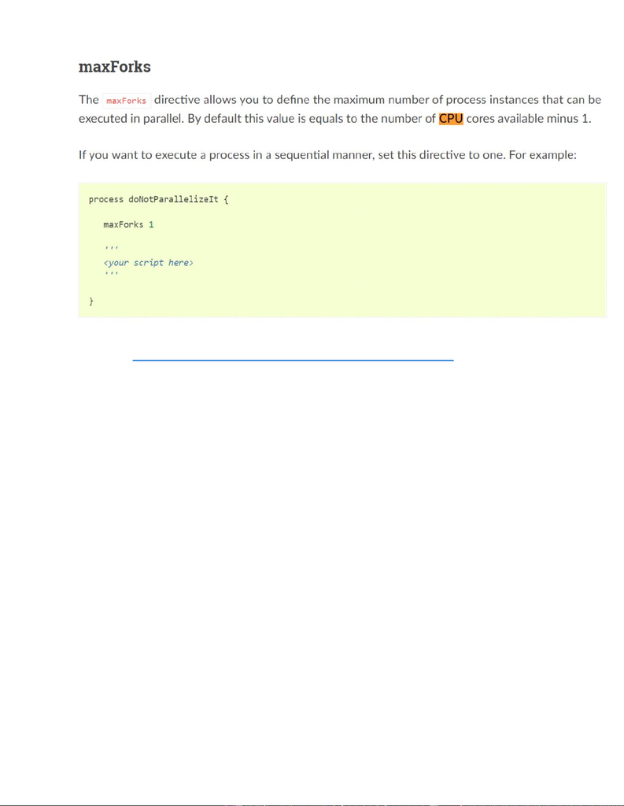

Debugging tips! GitHub - danrlu/Nextflow_cheatsheet: Useful tips to get started with Nextflow

Nextflow Page 10

[figure not shown]

Allowing conational execution of certain processes: https://github.com/nextflow-io/nextflow/issues/923

It is super helpful to subsample the fastq files, I made a little subsample script that runs decently fast

(like 1 min for a 5-9GB file) I hope that’s fast.

I think entering names of things without paths might be optimal…just a feeling I am getting of working

wit hthe workflow currently (9/21)

https://nf-co.re/tools/#creating-a-new-pipeline nf-core has recommendations on how to make a good

pipeline. Additional documentation on this process: https://nf-co.re/developers/adding_pipelines

To view your channels/outputs: GitHub - danrlu/Nextflow_cheatsheet: Useful tips to get started with

Nextflow

Best Practices

Wednesday, August 11, 2021

4:11 PM

Nextflow Page 11

[figure not shown]

https://github.com/dolphinnext/dolphinnext-tutorial

Here is their docker image with instructions of how to run:

https://hub.docker.com/r/ummsbiocore/dolphinnext-docker

mkozubov@tenayathera.com

DolphinNext

Thursday, September 16, 2021

3:24 PM

Nextflow Page 12

[figure not shown]

Nextflow Training Workshop - July 2020 - Day 5: 22:45

He is saying that Nextflow can invoke cloud bursts. Particular tasks can use particular resources.

Yet another tutorial: https://github.com/seqeralabs/nextflow-tutorial#Nextflow-in-a-nutshell

Tutorials

Monday, September 27, 2021

9:12 AM

Nextflow Page 13

[figure not shown]

Most of the instructions are on https://github.com/seqeralabs/nf-tower,

But they are misleading about the SMTP stuff, that is literally as easy as office.email.com or some shit

for the TOWER_SMTP_HOST.

Well don't forget to run the backend in the proper conda env.

Also putting the token inside of the configuration file…doesn't work. Need to run the command on the

command line like very strange…

"nextflow run main.nf -with-tower 'http://bioinformatics.tenaya.local:8000/api'"

NVM I FIGURED IT OUT. It only needs the -with-tower flag if you don't have the stuff in the configuration

file…

Nf-tower

Thursday, September 30, 2021

1:51 PM

Nextflow Page 14

[figure not shown]

Title: Nextflow with AWS: https://genomics-nf.workshop.aws/intro.html

Wants me to make a new user? Called it workshop wand the password is "Sample1!"

•

https://docs.opendata.aws/genomics-workflows/orchestration/nextflow/nextflow-overview.html

https://docs.opendata.aws/genomics-workflows/orchestration/cost-effective-workflows/cost-effective-

workflows.html

Cloud

Monday, October 18, 2021

9:47 AM

Nextflow Page 15